# Risk Factor Analysis

## Outcome Variable

**Outcome Variable:** wast_rec90d

## Predictor Variables

**Intervention Variable:** predfeed3

**Adjustment Set:**

unadjusted

## Stratifying Variables

The analysis was stratified on these variable(s):

- agecat
- studyid
- country

## Data Summary

| agecat | studyid | country | predfeed3 | wast_rec90d | n_cell | n |
| --- | --- | --- | --- | --- | --- | --- |
| 0-24 months | EE | PAKISTAN | 1 | 0 | 14 | 30 |
| 0-24 months | EE | PAKISTAN | 1 | 1 | 16 | 30 |
| 0-24 months | EE | PAKISTAN | 0 | 0 | 0 | 30 |
| 0-24 months | EE | PAKISTAN | 0 | 1 | 0 | 30 |
| 0-24 months | GMS-Nepal | NEPAL | 1 | 0 | 185 | 491 |
| 0-24 months | GMS-Nepal | NEPAL | 1 | 1 | 231 | 491 |
| 0-24 months | GMS-Nepal | NEPAL | 0 | 0 | 32 | 491 |
| 0-24 months | GMS-Nepal | NEPAL | 0 | 1 | 43 | 491 |
| 0-24 months | MAL-ED | BANGLADESH | 1 | 0 | 33 | 117 |
| 0-24 months | MAL-ED | BANGLADESH | 1 | 1 | 68 | 117 |
| 0-24 months | MAL-ED | BANGLADESH | 0 | 0 | 8 | 117 |
| 0-24 months | MAL-ED | BANGLADESH | 0 | 1 | 8 | 117 |
| 0-24 months | MAL-ED | BRAZIL | 1 | 0 | 5 | 22 |
| 0-24 months | MAL-ED | BRAZIL | 1 | 1 | 9 | 22 |
| 0-24 months | MAL-ED | BRAZIL | 0 | 0 | 1 | 22 |
| 0-24 months | MAL-ED | BRAZIL | 0 | 1 | 7 | 22 |
| 0-24 months | MAL-ED | INDIA | 1 | 0 | 43 | 162 |
| 0-24 months | MAL-ED | INDIA | 1 | 1 | 67 | 162 |
| 0-24 months | MAL-ED | INDIA | 0 | 0 | 19 | 162 |
| 0-24 months | MAL-ED | INDIA | 0 | 1 | 33 | 162 |
| 0-24 months | MAL-ED | NEPAL | 1 | 0 | 11 | 96 |
| 0-24 months | MAL-ED | NEPAL | 1 | 1 | 35 | 96 |
| 0-24 months | MAL-ED | NEPAL | 0 | 0 | 9 | 96 |
| 0-24 months | MAL-ED | NEPAL | 0 | 1 | 41 | 96 |
| 0-24 months | MAL-ED | PERU | 1 | 0 | 3 | 33 |
| 0-24 months | MAL-ED | PERU | 1 | 1 | 12 | 33 |
| 0-24 months | MAL-ED | PERU | 0 | 0 | 3 | 33 |
| 0-24 months | MAL-ED | PERU | 0 | 1 | 15 | 33 |
| 0-24 months | MAL-ED | SOUTH AFRICA | 1 | 0 | 4 | 77 |
| 0-24 months | MAL-ED | SOUTH AFRICA | 1 | 1 | 12 | 77 |

[output cut: 78 more lines]

The following strata were considered:

- agecat: 0-24 months, studyid: EE, country: PAKISTAN
- agecat: 0-24 months, studyid: GMS-Nepal, country: NEPAL
- agecat: 0-24 months, studyid: MAL-ED, country: BANGLADESH
- agecat: 0-24 months, studyid: MAL-ED, country: BRAZIL
- agecat: 0-24 months, studyid: MAL-ED, country: INDIA
- agecat: 0-24 months, studyid: MAL-ED, country: NEPAL
- agecat: 0-24 months, studyid: MAL-ED, country: PERU
- agecat: 0-24 months, studyid: MAL-ED, country: SOUTH AFRICA
- agecat: 0-24 months, studyid: MAL-ED, country: TANZANIA, UNITED REPUBLIC OF
- agecat: 0-6 months, studyid: EE, country: PAKISTAN
- agecat: 0-6 months, studyid: GMS-Nepal, country: NEPAL
- agecat: 0-6 months, studyid: MAL-ED, country: BANGLADESH
- agecat: 0-6 months, studyid: MAL-ED, country: BRAZIL
- agecat: 0-6 months, studyid: MAL-ED, country: INDIA
- agecat: 0-6 months, studyid: MAL-ED, country: NEPAL
- agecat: 0-6 months, studyid: MAL-ED, country: PERU
- agecat: 0-6 months, studyid: MAL-ED, country: SOUTH AFRICA
- agecat: 0-6 months, studyid: MAL-ED, country: TANZANIA, UNITED REPUBLIC OF
- agecat: 6-24 months, studyid: EE, country: PAKISTAN
- agecat: 6-24 months, studyid: GMS-Nepal, country: NEPAL
- agecat: 6-24 months, studyid: MAL-ED, country: BANGLADESH
- agecat: 6-24 months, studyid: MAL-ED, country: BRAZIL
- agecat: 6-24 months, studyid: MAL-ED, country: INDIA
- agecat: 6-24 months, studyid: MAL-ED, country: NEPAL
- agecat: 6-24 months, studyid: MAL-ED, country: PERU
- agecat: 6-24 months, studyid: MAL-ED, country: SOUTH AFRICA
- agecat: 6-24 months, studyid: MAL-ED, country: TANZANIA, UNITED REPUBLIC OF

### Dropped Strata

Some strata were dropped due to rare outcomes:

- agecat: 0-24 months, studyid: EE, country: PAKISTAN
- agecat: 0-24 months, studyid: MAL-ED, country: BRAZIL
- agecat: 0-24 months, studyid: MAL-ED, country: PERU
- agecat: 0-24 months, studyid: MAL-ED, country: SOUTH AFRICA
- agecat: 0-24 months, studyid: MAL-ED, country: TANZANIA, UNITED REPUBLIC OF
- agecat: 0-6 months, studyid: EE, country: PAKISTAN
- agecat: 0-6 months, studyid: MAL-ED, country: BANGLADESH
- agecat: 0-6 months, studyid: MAL-ED, country: BRAZIL
- agecat: 0-6 months, studyid: MAL-ED, country: NEPAL
- agecat: 0-6 months, studyid: MAL-ED, country: PERU
- agecat: 0-6 months, studyid: MAL-ED, country: SOUTH AFRICA
- agecat: 0-6 months, studyid: MAL-ED, country: TANZANIA, UNITED REPUBLIC OF
- agecat: 6-24 months, studyid: EE, country: PAKISTAN
- agecat: 6-24 months, studyid: MAL-ED, country: BANGLADESH
- agecat: 6-24 months, studyid: MAL-ED, country: BRAZIL
- agecat: 6-24 months, studyid: MAL-ED, country: NEPAL
- agecat: 6-24 months, studyid: MAL-ED, country: PERU
- agecat: 6-24 months, studyid: MAL-ED, country: SOUTH AFRICA
- agecat: 6-24 months, studyid: MAL-ED, country: TANZANIA, UNITED REPUBLIC OF

## Methods Detail

We’re interested in the causal parameters $E[Y_a]$ for all values of $a \in \mathcal{A}$. These parameters represent the mean outcome if, possibly contrary to fact, we intervened to set all units to have $A=a$. Under the randomization and positivity assumptions, these are identified by the statistical parameters $\psi_a=E_W[E_{Y|A,W}(Y|A=a,W)]$. In addition, we’re interested in the mean of $Y$, $E[Y]$ under no intervention (the observed mean). We will estimate these parameters by using SuperLearner to fit the relevant likelihood factors – $E_{Y|A,W}(Y|A=a,W)$ and $p(A=a|W)$, and then updating our likelihood fit using a joint TMLE.

For unadjusted analyses ($W=\{\}$), initial likelihoods were estimated using Lrnr_glm to estimate the simple $E(Y|A)$ and Lrnr_mean to estimate $p(A)$. For adjusted analyses, a small library containing Lrnr_glmnet, Lrnr_xgboost, and Lrnr_mean was used.

Having estimated these parameters, we will then use the delta method to estimate relative risks and attributable risks relative to a prespecified baseline level of $A$.

# Results Detail

## Results Plots

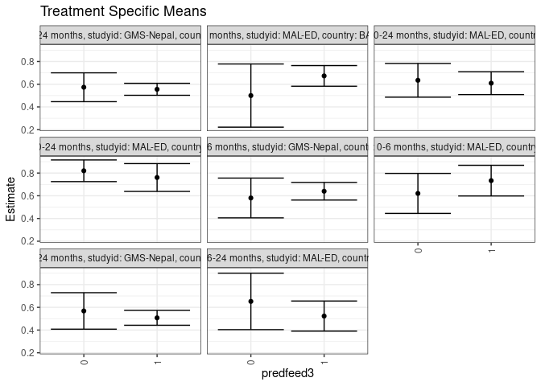

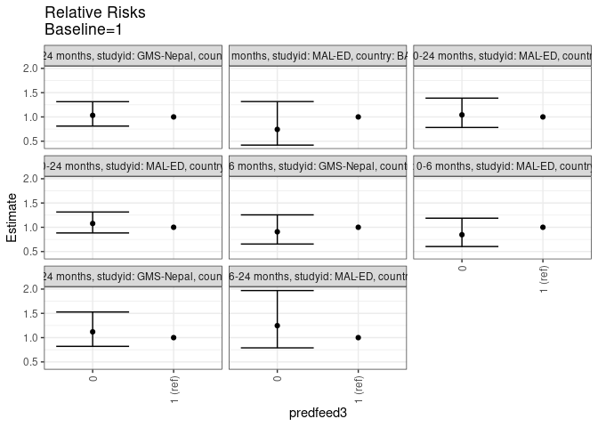

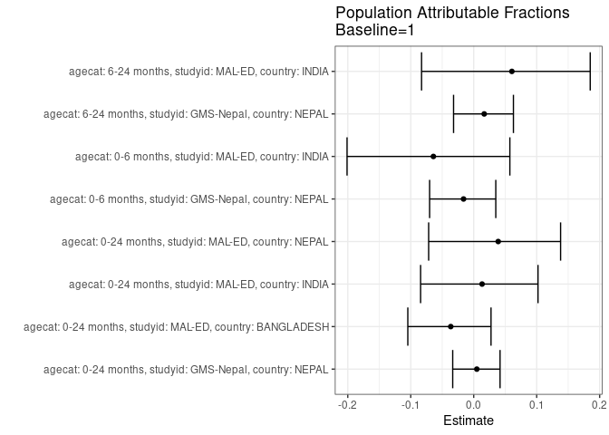

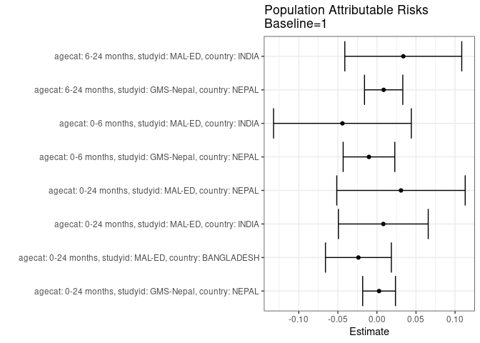

## Results Table

### Parameter: TSM

| agecat | studyid | country | intervention_level | baseline_level | estimate | ci_lower | ci_upper |
| --- | --- | --- | --- | --- | --- | --- | --- |
| 0-24 months | GMS-Nepal | NEPAL | 1 | NA | 0.5552885 | 0.5025632 | 0.6080137 |
| 0-24 months | GMS-Nepal | NEPAL | 0 | NA | 0.5733333 | 0.4464146 | 0.7002520 |
| 0-24 months | MAL-ED | BANGLADESH | 1 | NA | 0.6732673 | 0.5822997 | 0.7642350 |
| 0-24 months | MAL-ED | BANGLADESH | 0 | NA | 0.5000000 | 0.2219425 | 0.7780575 |
| 0-24 months | MAL-ED | INDIA | 1 | NA | 0.6090909 | 0.5084866 | 0.7096952 |
| 0-24 months | MAL-ED | INDIA | 0 | NA | 0.6346154 | 0.4862931 | 0.7829377 |
| 0-24 months | MAL-ED | NEPAL | 1 | NA | 0.7608696 | 0.6384483 | 0.8832909 |
| 0-24 months | MAL-ED | NEPAL | 0 | NA | 0.8200000 | 0.7247720 | 0.9152280 |
| 0-6 months | GMS-Nepal | NEPAL | 1 | NA | 0.6400000 | 0.5624099 | 0.7175901 |
| 0-6 months | GMS-Nepal | NEPAL | 0 | NA | 0.5806452 | 0.4056011 | 0.7556893 |
| 0-6 months | MAL-ED | INDIA | 1 | NA | 0.7333333 | 0.5982681 | 0.8683986 |
| 0-6 months | MAL-ED | INDIA | 0 | NA | 0.6206897 | 0.4444990 | 0.7968803 |
| 6-24 months | GMS-Nepal | NEPAL | 1 | NA | 0.5075188 | 0.4420557 | 0.5729819 |
| 6-24 months | GMS-Nepal | NEPAL | 0 | NA | 0.5681818 | 0.4076156 | 0.7287481 |
| 6-24 months | MAL-ED | INDIA | 1 | NA | 0.5230769 | 0.3907677 | 0.6553862 |
| 6-24 months | MAL-ED | INDIA | 0 | NA | 0.6521739 | 0.4038225 | 0.9005253 |

### Parameter: E(Y)

| agecat | studyid | country | intervention_level | baseline_level | estimate | ci_lower | ci_upper |
| --- | --- | --- | --- | --- | --- | --- | --- |
| 0-24 months | GMS-Nepal | NEPAL | NA | NA | 0.5580448 | 0.5093588 | 0.6067308 |
| 0-24 months | MAL-ED | BANGLADESH | NA | NA | 0.6495726 | 0.5607849 | 0.7383604 |
| 0-24 months | MAL-ED | INDIA | NA | NA | 0.6172840 | 0.5340594 | 0.7005085 |
| 0-24 months | MAL-ED | NEPAL | NA | NA | 0.7916667 | 0.7146386 | 0.8686947 |
| 0-6 months | GMS-Nepal | NEPAL | NA | NA | 0.6298343 | 0.5587812 | 0.7008873 |
| 0-6 months | MAL-ED | INDIA | NA | NA | 0.6891892 | 0.5810852 | 0.7972932 |
| 6-24 months | GMS-Nepal | NEPAL | NA | NA | 0.5161290 | 0.4555456 | 0.5767125 |
| 6-24 months | MAL-ED | INDIA | NA | NA | 0.5568182 | 0.4384773 | 0.6751591 |

### Parameter: RR

| agecat | studyid | country | intervention_level | baseline_level | estimate | ci_lower | ci_upper |
| --- | --- | --- | --- | --- | --- | --- | --- |
| 0-24 months | GMS-Nepal | NEPAL | 1 | 1 | 1.0000000 | 1.0000000 | 1.000000 |
| 0-24 months | GMS-Nepal | NEPAL | 0 | 1 | 1.0324964 | 0.8114501 | 1.313758 |
| 0-24 months | MAL-ED | BANGLADESH | 1 | 1 | 1.0000000 | 1.0000000 | 1.000000 |
| 0-24 months | MAL-ED | BANGLADESH | 0 | 1 | 0.7426471 | 0.4190238 | 1.316213 |
| 0-24 months | MAL-ED | INDIA | 1 | 1 | 1.0000000 | 1.0000000 | 1.000000 |
| 0-24 months | MAL-ED | INDIA | 0 | 1 | 1.0419059 | 0.7826093 | 1.387113 |
| 0-24 months | MAL-ED | NEPAL | 1 | 1 | 1.0000000 | 1.0000000 | 1.000000 |
| 0-24 months | MAL-ED | NEPAL | 0 | 1 | 1.0777143 | 0.8831354 | 1.315164 |
| 0-6 months | GMS-Nepal | NEPAL | 1 | 1 | 1.0000000 | 1.0000000 | 1.000000 |
| 0-6 months | GMS-Nepal | NEPAL | 0 | 1 | 0.9072581 | 0.6555629 | 1.255588 |
| 0-6 months | MAL-ED | INDIA | 1 | 1 | 1.0000000 | 1.0000000 | 1.000000 |
| 0-6 months | MAL-ED | INDIA | 0 | 1 | 0.8463950 | 0.6034039 | 1.187239 |
| 6-24 months | GMS-Nepal | NEPAL | 1 | 1 | 1.0000000 | 1.0000000 | 1.000000 |
| 6-24 months | GMS-Nepal | NEPAL | 0 | 1 | 1.1195286 | 0.8203397 | 1.527836 |
| 6-24 months | MAL-ED | INDIA | 1 | 1 | 1.0000000 | 1.0000000 | 1.000000 |
| 6-24 months | MAL-ED | INDIA | 0 | 1 | 1.2468031 | 0.7893061 | 1.969474 |

### Parameter: PAR

| agecat | studyid | country | intervention_level | baseline_level | estimate | ci_lower | ci_upper |
| --- | --- | --- | --- | --- | --- | --- | --- |
| 0-24 months | GMS-Nepal | NEPAL | 1 | NA | 0.0027563 | -0.0182167 | 0.0237294 |
| 0-24 months | MAL-ED | BANGLADESH | 1 | NA | -0.0236947 | -0.0658584 | 0.0184690 |
| 0-24 months | MAL-ED | INDIA | 1 | NA | 0.0081930 | -0.0492741 | 0.0656602 |
| 0-24 months | MAL-ED | NEPAL | 1 | NA | 0.0307971 | -0.0513830 | 0.1129772 |
| 0-6 months | GMS-Nepal | NEPAL | 1 | NA | -0.0101657 | -0.0432004 | 0.0228689 |
| 0-6 months | MAL-ED | INDIA | 1 | NA | -0.0441441 | -0.1323123 | 0.0440240 |
| 6-24 months | GMS-Nepal | NEPAL | 1 | NA | 0.0086102 | -0.0158881 | 0.0331086 |
| 6-24 months | MAL-ED | INDIA | 1 | NA | 0.0337413 | -0.0410835 | 0.1085660 |

### Parameter: PAF

| agecat | studyid | country | intervention_level | baseline_level | estimate | ci_lower | ci_upper |
| --- | --- | --- | --- | --- | --- | --- | --- |
| 0-24 months | GMS-Nepal | NEPAL | 1 | NA | 0.0049393 | -0.0333585 | 0.0418177 |
| 0-24 months | MAL-ED | BANGLADESH | 1 | NA | -0.0364773 | -0.1046400 | 0.0274793 |
| 0-24 months | MAL-ED | INDIA | 1 | NA | 0.0132727 | -0.0843541 | 0.1021100 |
| 0-24 months | MAL-ED | NEPAL | 1 | NA | 0.0389016 | -0.0715585 | 0.1379751 |
| 0-6 months | GMS-Nepal | NEPAL | 1 | NA | -0.0161404 | -0.0700494 | 0.0350528 |
| 0-6 months | MAL-ED | INDIA | 1 | NA | -0.0640523 | -0.2011552 | 0.0574014 |
| 6-24 months | GMS-Nepal | NEPAL | 1 | NA | 0.0166823 | -0.0320002 | 0.0630683 |
| 6-24 months | MAL-ED | INDIA | 1 | NA | 0.0605965 | -0.0828181 | 0.1850165 |